Lake Name: Hatch Lake

Lake acreage: 134.9

County: MADISON

PWLID: 0602-0112

Waterbody Classification: B

Coordinates: 42.834598,-75.677803

Is this waterbody a public water supply: No

Are there DOH desingated beaches on this waterbody: Yes

Open Water Indicators

2018 Sampling Results

Seasonal Change

06-03

06-17

07-01

07-15

07-29

08-12

08-26

09-08

Clarity (m)

3.05

4.80

5.65

6.25

4.75

5.80

4.70

4.70

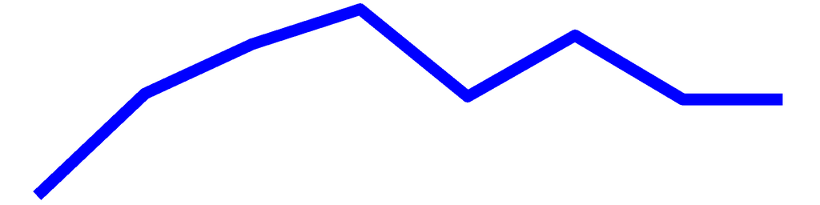

Surface TP (mg/L)

0.01

0.01

0.01

0.01

0.01

0.01

0.01

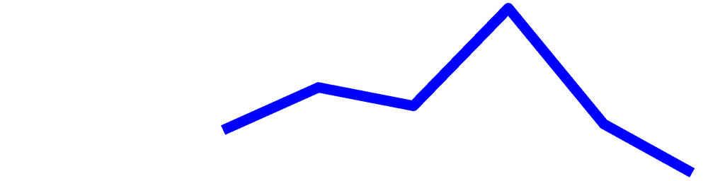

Surface TDP (mg/L)

0.01

0.00

0.00

0.00

0.00

0.00

0.00

0.00

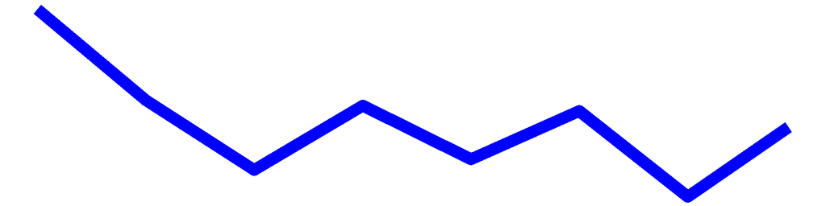

Deep TP (mg/L)

0.02

0.02

0.01

0.04

0.02

0.02

0.06

0.03

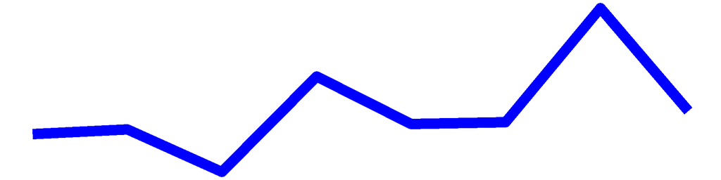

Deep TDP (mg/L)

0.01

0.01

0.00

0.01

0.01

0.01

0.03

0.01

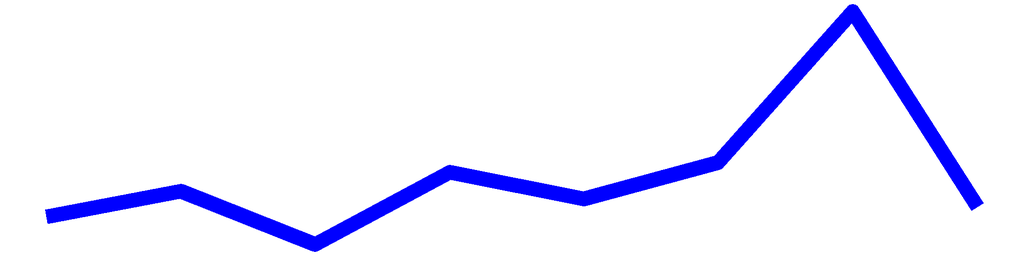

TN (mg/L)

0.47

0.39

0.25

0.40

0.35

0.29

0.19

1.05

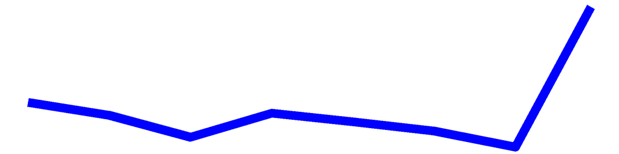

TDN (mg/L)

0.50

0.37

0.04

0.35

0.35

0.27

0.19

0.89

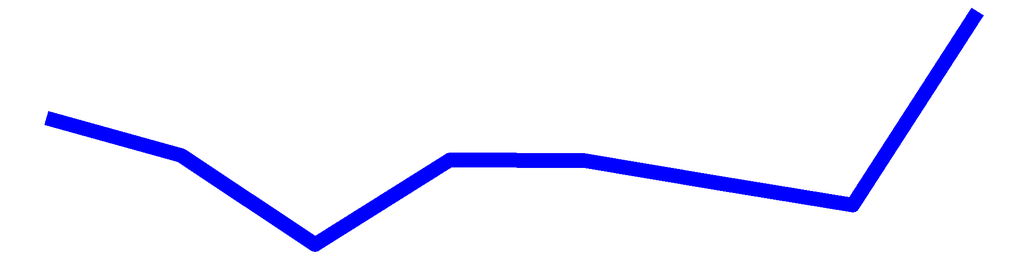

TN:TP

64.16

35.73

51.41

46.31

32.09

26.85

164.77

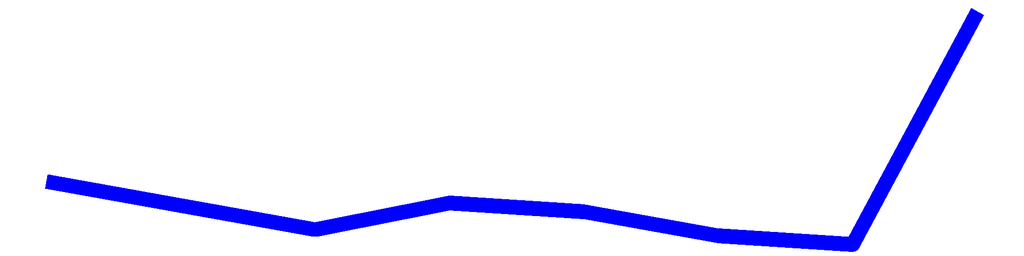

Surface NH3 (mg/L)

0.02

0.00

0.00

0.00

0.01

0.04

0.01

0.00

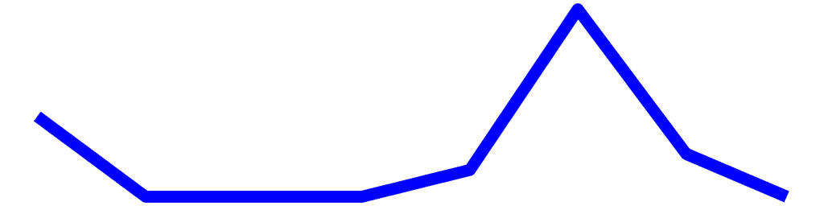

Deep NH3 (mg/L)

0.04

0.05

0.05

0.03

0.06

0.05

0.18

0.02

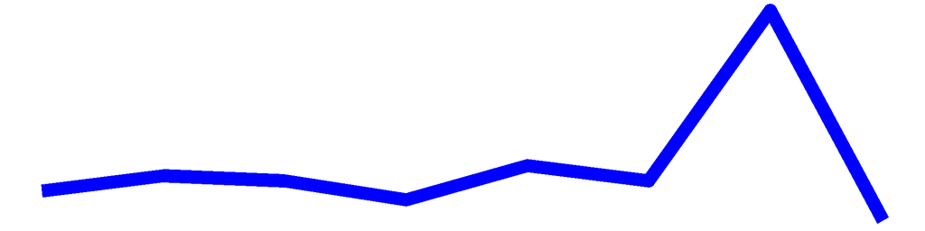

Chl.a (ug/L)

5.00

1.10

1.20

2.00

1.00

2.30

2.40

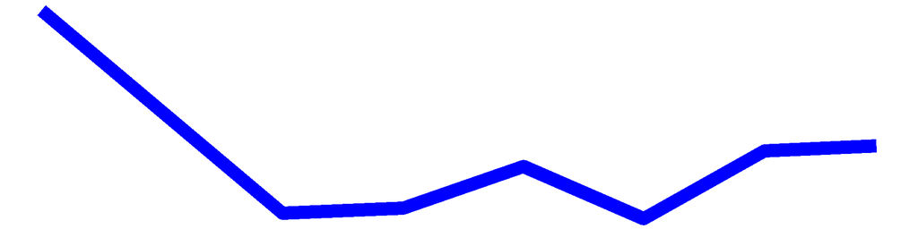

pH

7.69

7.21

7.59

7.30

7.33

7.30

7.22

6.92

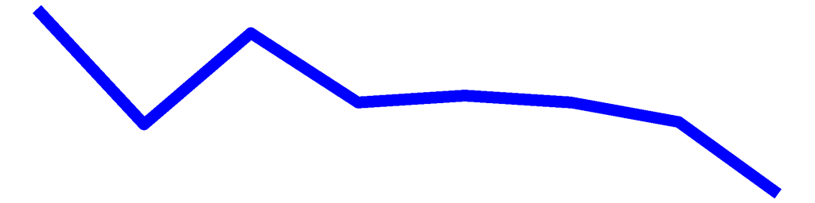

Cond (umho/cm)

204.00

199.30

203.70

246.40

230.80

213.00

218.10

143.30

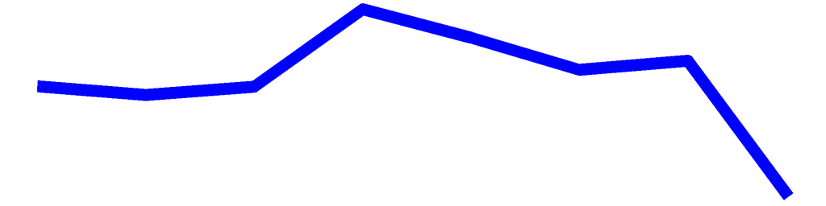

Surface Calcium (mg/L)

Bottom Calcium (mg/L)

Surface Chloride (mg/L)

18.20

17.40

Bottom Chloride (mg/L)

Upper Temp (degC)

22.00

21.00

27.00

26.50

25.00

26.50

24.00

25.00

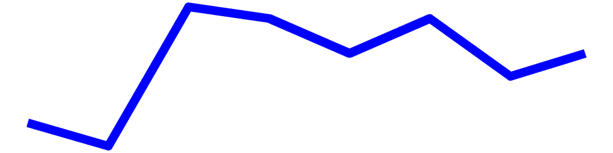

Deep Temp (degC)

12.00

9.00

19.00

16.00

15.00

9.00

9.00

10.00

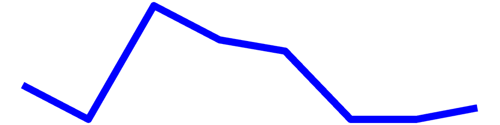

FP BG Chl.a (ug/L)

8.29

2.30

1.55

1.08

2.12

1.45

2.06

3.10

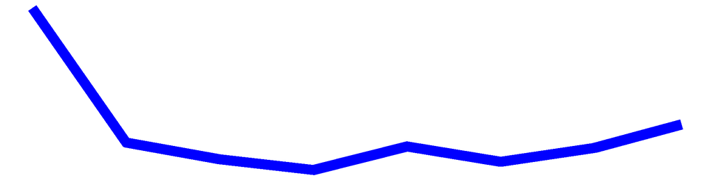

## Hatch Lake – Sampling Season Results

### HABs Status

#### Open Water Algae

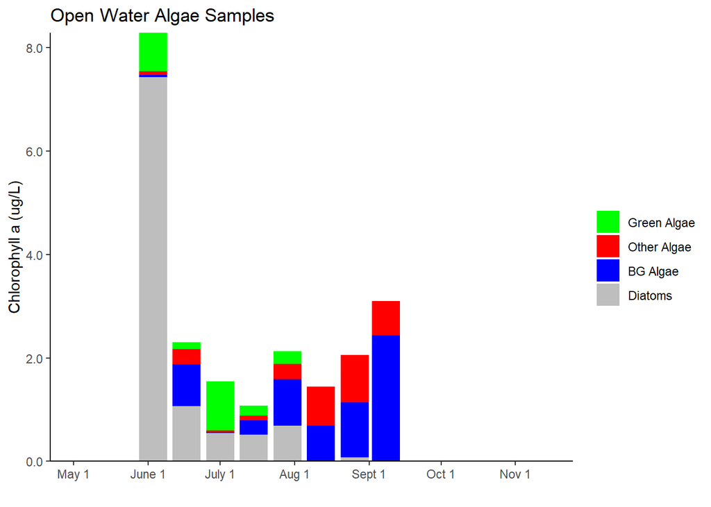

#### Shoreline Algae

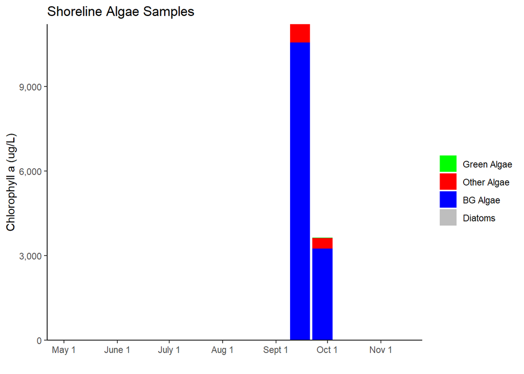

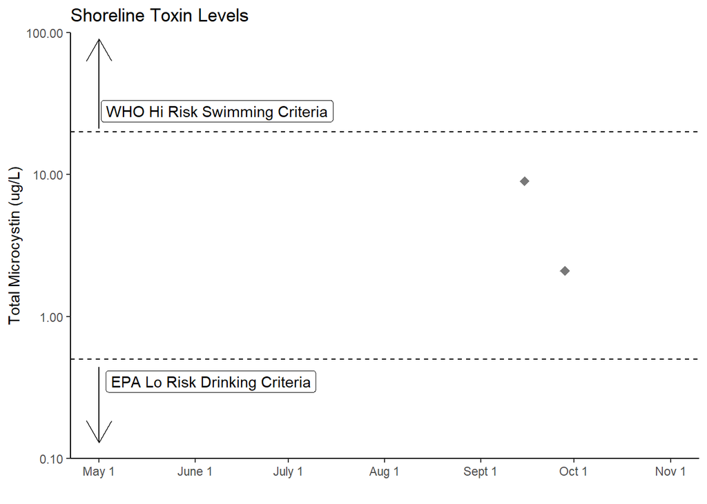

## Hatch Lake Long-Term Trend Analysis

#### Clarity

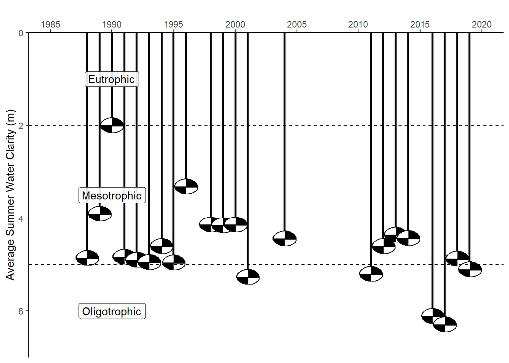

#### Chlorophyll *a*

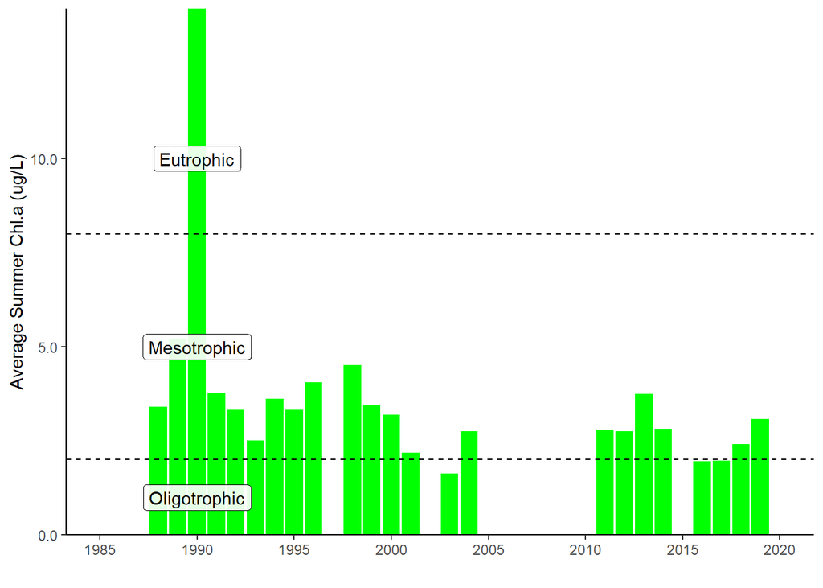

#### Surface and Deep Phosphorus

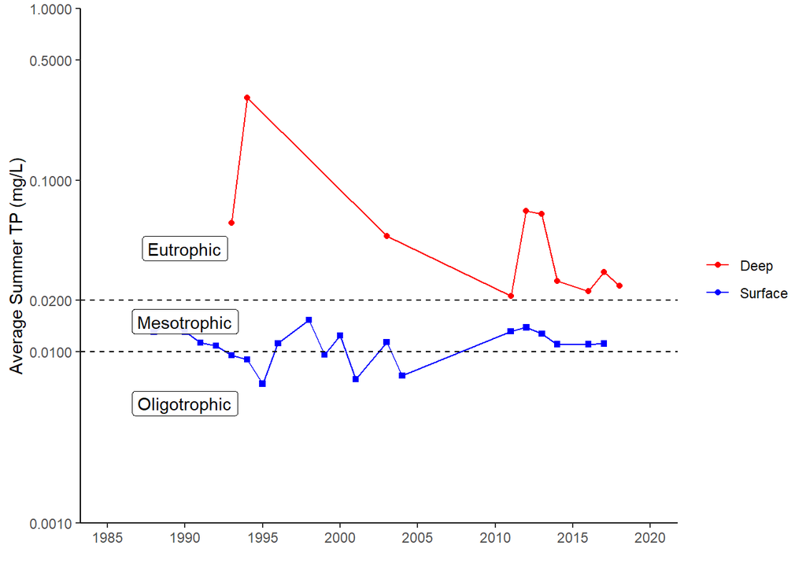

#### Nitrogen

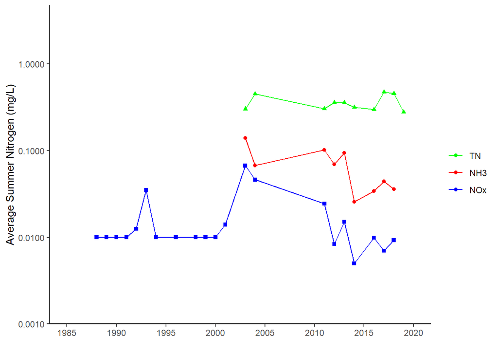

#### TN : TP

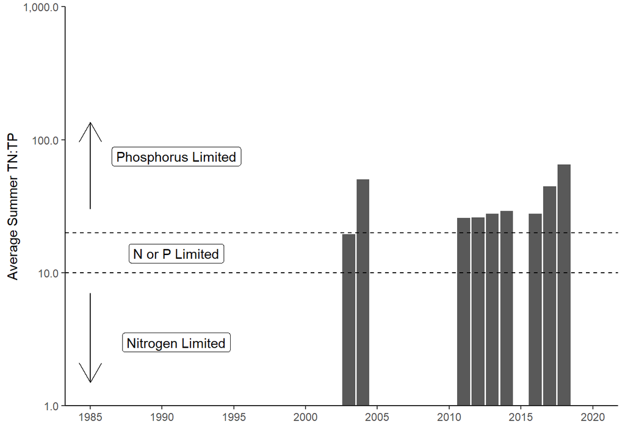

#### pH

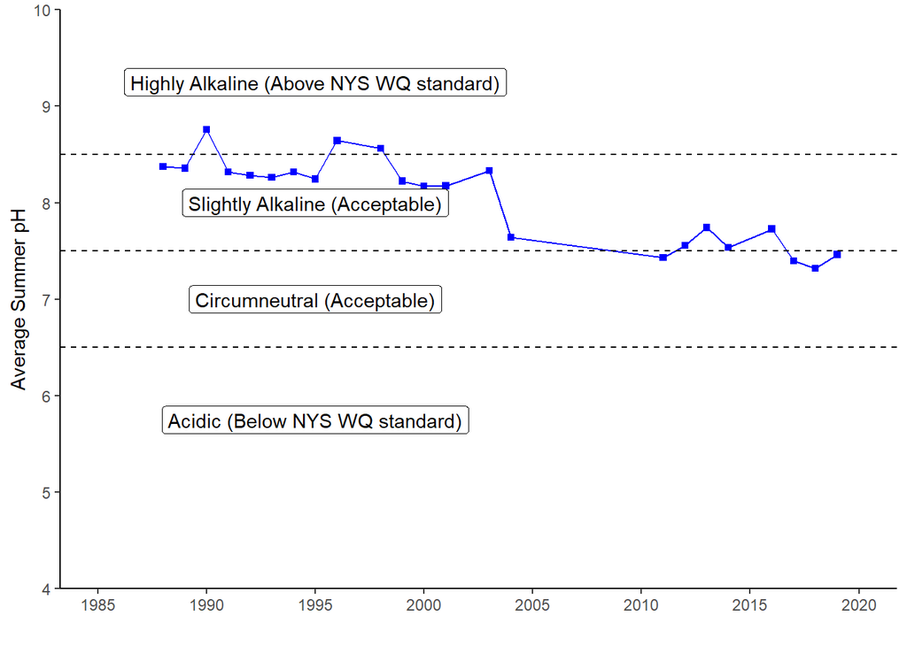

#### Specific Conductance

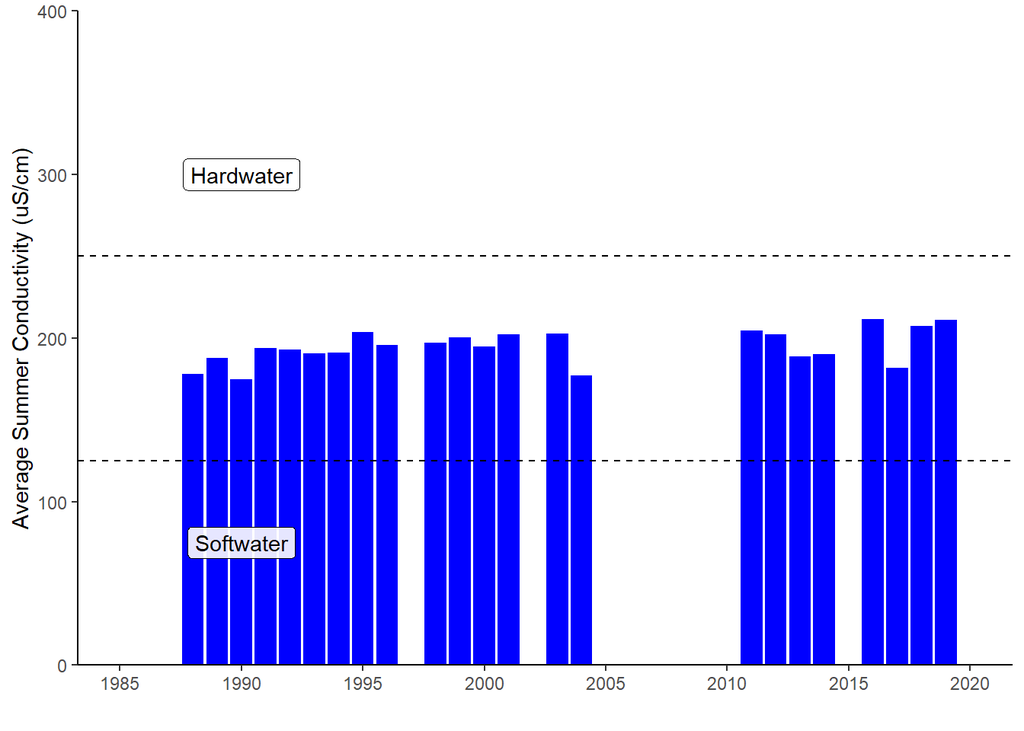

#### Calcium

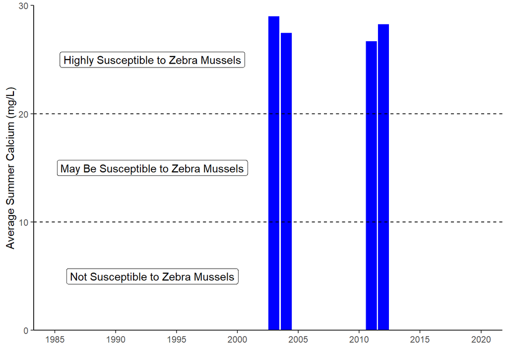

#### Chloride

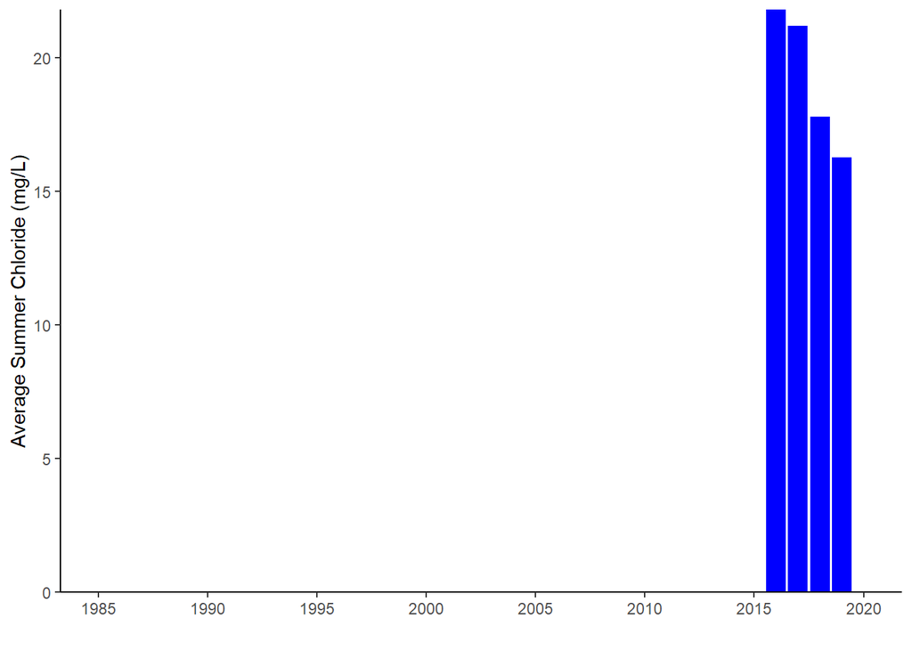

#### Color

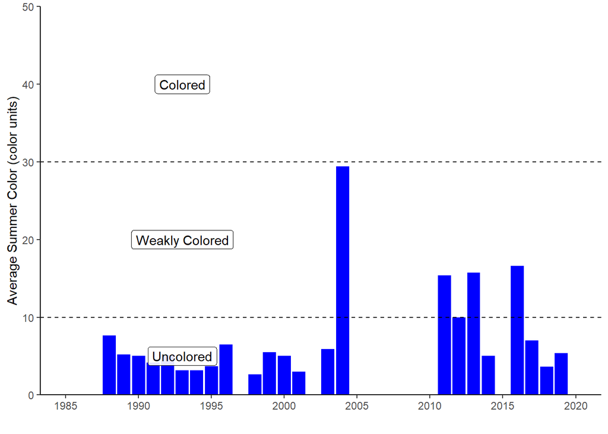

#### Surface and Deep Temperature

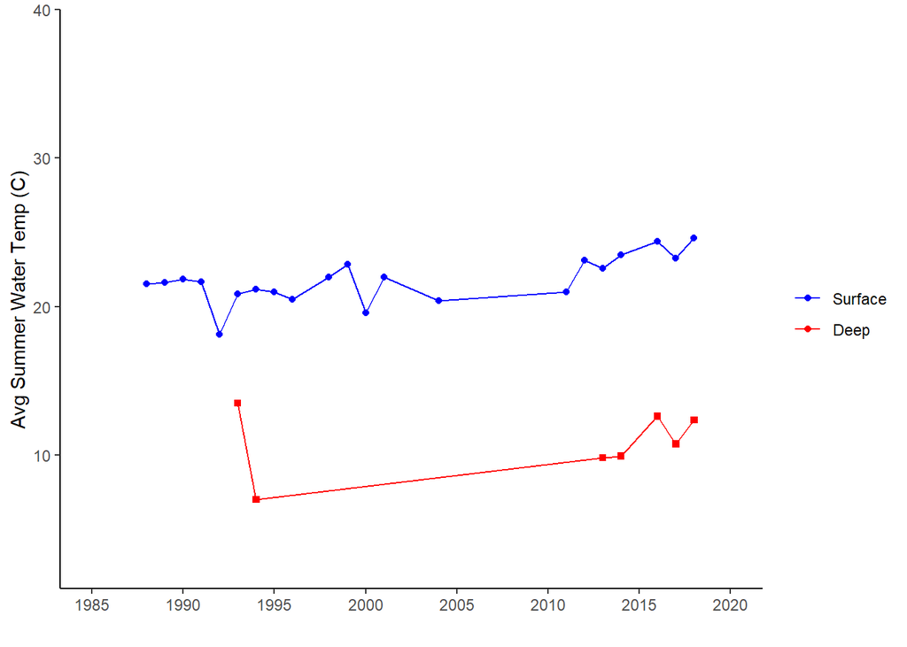

#### Lake Perception

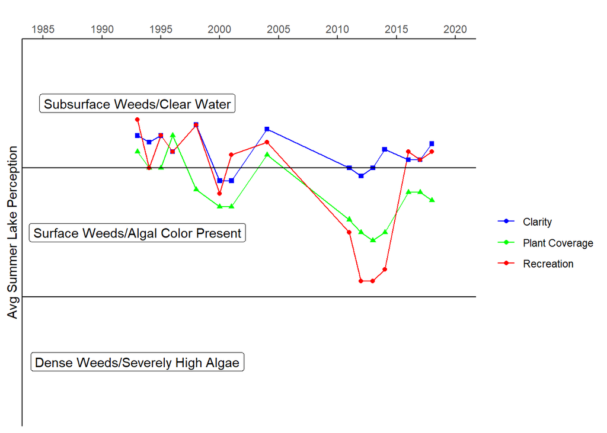

## Hatch Lake - In-Season Analysis

#### In Season Water Clarity

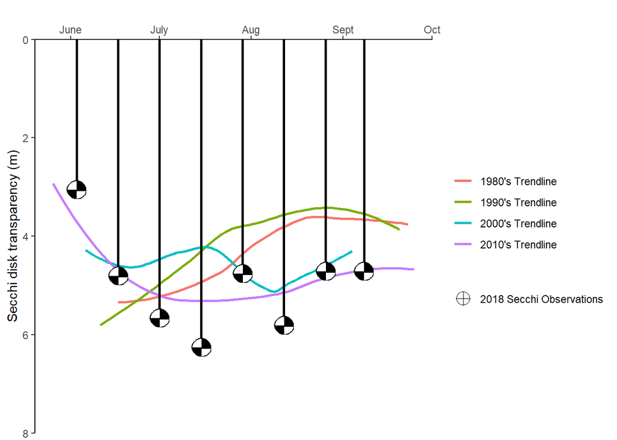

#### In Season Water Temperature

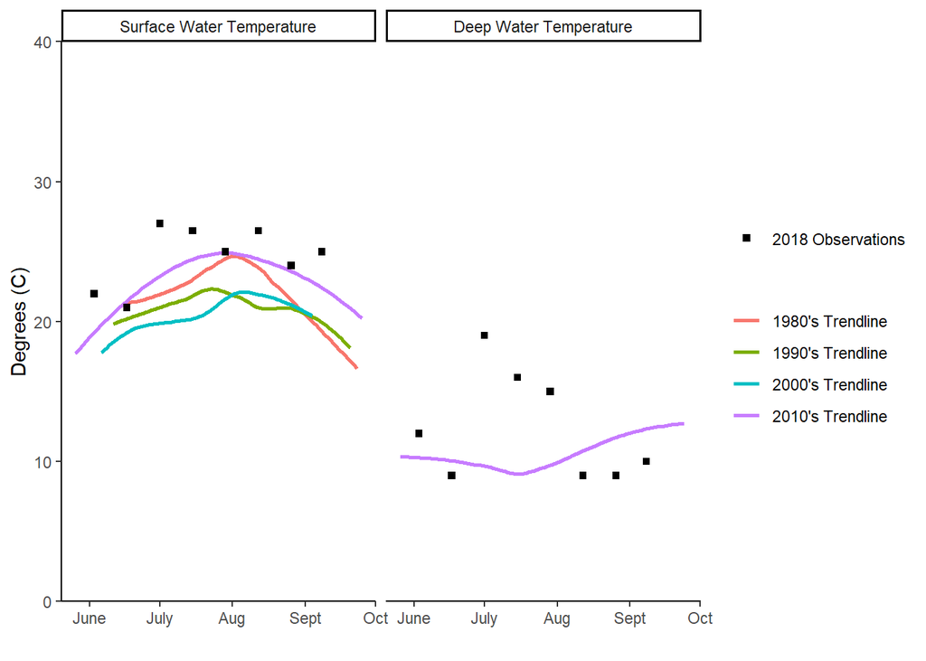